# SV Exploration

2023-06-28

I am going to take all of Nico’s cleaning code.

```r
load("Data/wvs_timeseries.rdata")

d <- data1 %>%
  haven::zap_labels()

rm(data1)

d_short <- d %>%
  select(S002VS,
         COUNTRY_ALPHA,
         S020,
         S003,
         X001,
         X003,
         X007,
         F118:F123,
         A124_06) %>%
  rename(wave = S002VS,
         country = COUNTRY_ALPHA,
         country_code = S003,
         year_survey = S020,
         sex = X001,
         age = X003,
         marital_status = X007,
         just_homosexuality = F118,
         just_prostitution = F119,
         just_abortion = F120,
         just_divorce = F121,
         just_euthanasia = F122,
         just_suicide = F123,
         neigh_imm = A124_06)

d_short <- d_short %>%
  mutate(
    across(
      .cols = 6:14, # changed to include age and marital status
       ~ ifelse(
        . < 0,
        NA_real_,
        .
      ))
  )

summary_df <- d_short %>%
  select(country,
         wave,
         8:14) %>%
  pivot_longer(3:9,
               names_to = "variable",
               values_to = "response") %>%
  mutate(valid_response = if_else(
    is.na(response),0, 1
  )) %>%
  group_by(
    country,
    wave,
    variable
  ) %>%
  summarise(
    count = sum(valid_response)
  ) %>%
  ungroup()
```

I want to see start and end dates for individual questions in each country and the number of waves. This tells us how long the series is in that country for that question and how many distinct waves.

NOTE: I am also going to make a few new variables: - `age01` is (age-18)/(64-18) (should help lmer optimization) - `birthyear` (we will use more versions of this later) - `cohort10` (coarsened by 10s) - `cohort5` (coarsened by 5s)

```r
d_waves <- d_short %>%
  pivot_longer(just_homosexuality:neigh_imm,
               names_to = "variable",
               values_to = "y") %>%
  mutate(age01 = (age-18)/(64-18),
         birthyear = year_survey - age,
         cohort10 = floor(birthyear/10) * 10,
         cohort5  = floor(birthyear/5) * 5) %>%
  drop_na() %>%
  group_by(country, variable) %>%
  mutate(start = min(year_survey),
         end = max(year_survey),
         span = end-start,
         waves = n_distinct(wave),
         obs = n()) %>%
  ungroup()
```

Let’s look at best-case-scenario country/variables: those with all 7 waves.

```r
d7 <- d_waves %>%
  filter(waves == 7)

table(d7$country, d7$variable)
```

```
##
##       just_abortion just_divorce just_euthanasia just_homosexuality
##   ARG          6924         6922               0               6587
##   JPN          8477         8524               0               8245
##   MEX         11459        11442           11170              11296
##   USA         12613        12646               0              12464
##
##       just_prostitution just_suicide neigh_imm
##   ARG              6828         6796      7398
##   JPN                 0         8628         0
##   MEX             11395        11384     11686
##   USA                 0        12568     12761
```

This is very limiting! Only four countries.

Let’s relax it a tiny bit.

```r
d6 <- d_waves %>%
  filter(waves >= 5 & span >= 30)

table(d6$country, d6$variable)
```

```
##
##       just_abortion just_divorce just_euthanasia just_homosexuality
##   ARG          6924         6922            5641               6587
##   AUS          7726         7731               0               7652
##   CAN         10885        10933           10845              10704
##   JPN          8477         8524            6358               8245
##   MEX         11459        11442           11170              11296
##   SWE          6923         6985            6751               6762
##   USA         12613        12646           10343              12464
##   ZAF         16254        16185           15843              15962
##
##       just_prostitution just_suicide neigh_imm
##   ARG              6828         6796      7398
##   AUS              7711         7685      7884
##   CAN             10882        10815     10995
##   JPN              6658         8628         0
##   MEX             11395        11384     11686
##   SWE              5881         6541      7221
##   USA             10470        12568     12761
##   ZAF             16256        16219     13875
```

This might be good enough: 8 countries and in different areas of the world. I’m going to start with a very simple HAPC decomposition on each of these combos and see.

We need to make sure we have all the variables we need before nesting. For example, some of the cohort groups might be too small and we could combine them.

```r
table(d6$cohort10)
```

```
##
##   1880   1890   1900   1910   1920   1930   1940   1950   1960   1970   1980
##     34    446   3200  11330  27649  49508  75975 103998 103725  80974  55336
##   1990   2000
##  24094   1520
```

```r
table(d6$cohort5)
```

```
##
##  1885  1890  1895  1900  1905  1910  1915  1920  1925  1930  1935  1940  1945
##    34   119   327  1159  2041  4152  7178 11853 15796 21371 28137 33966 42009
##  1950  1955  1960  1965  1970  1975  1980  1985  1990  1995  2000
## 49445 54553 57284 46441 44681 36293 30242 25094 16373  7721  1520
```

```r
d6 <- d6 %>%
  mutate(
    cohort10b = factor(
      case_when(
        cohort10 < 1920 ~ 1920,
        cohort10 > 1990 ~ 1990,
        TRUE ~ cohort10
      )
    ),
    cohort5b = factor(
      case_when(
        cohort5 < 1920 ~ 1920,
        cohort5 > 1990 ~ 1900,
        TRUE ~ cohort5
      )
    )
  )
```

We are now ready to nest the df.

```r
d6nest <- d6 %>%
  group_by(country, variable) %>%
  nest()
```

Before running it on everything, I am going to do a quick test on one variable in one country (prostitution in South Africa).

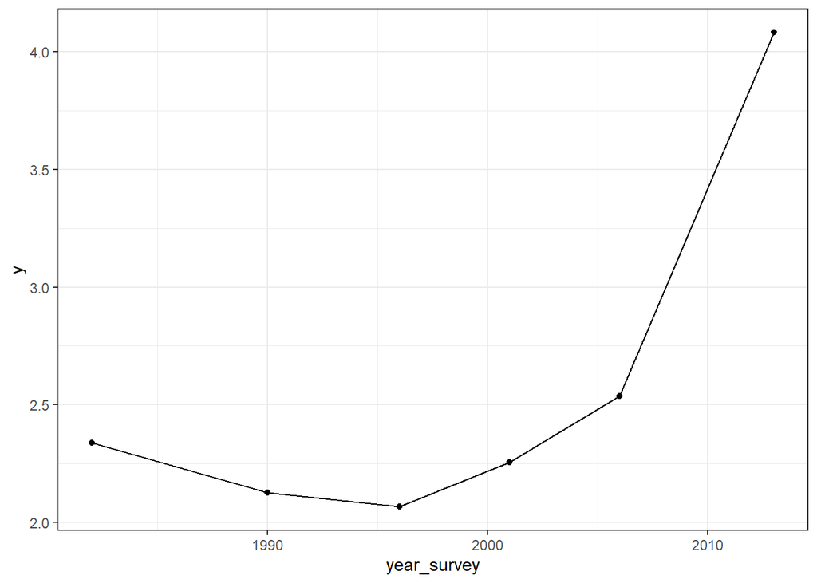

```r
maxobs <- max(d6$obs)

d6test <- d6 %>%
  filter(obs == maxobs)

d6test %>%
  group_by(year_survey) %>%
  summarize(y = mean(y)) %>%
  ggplot(aes(x = year_survey,
             y = y)) +
  geom_point() +
  geom_line()
```

OK you can see that the average goes up here pretty dramatically. Even just looking at this, it’s got to be a period effect but let’s look more closely at the cohorts separately.

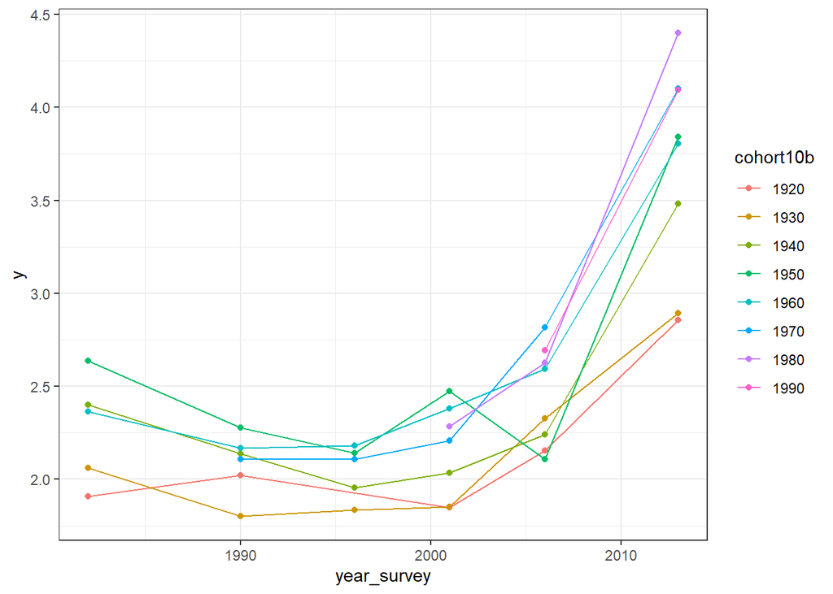

```r
d6test %>%
  group_by(cohort10b,
           year_survey) %>%
  summarize(y = mean(y)) %>%
  ggplot(aes(x = year_survey,
             y = y,
             group = cohort10b,
             color = cohort10b)) +
  geom_point() +
  geom_line()
```

There may be some differences by cohort but everyone changes pretty dramatically in most recent waves.

We can use FE ANOVA to get an approximation of the “delta” statistic that Omar and I use to calculate cultural durability. We could choose different coarsenings in the final version but I will use `cohort10b` here for simplicity.

```r
library(rstatix)
fe1 <- lm(y ~ age01 + I(age01^2) + cohort10b + factor(year_survey),
          data = d6test)

at <- anova_test(fe1, detailed = TRUE)

C_mse <- at[3,2] / at[3,4]
P_mse <- at[4,2] / at[4,4]

Delta <- C_mse / (C_mse + P_mse)
Delta
```

```
## [1] 0.01009962
```

Only 1% of the systematic change here looks like cohort replacement.

Let’s extend this to the same question but for all available countries.

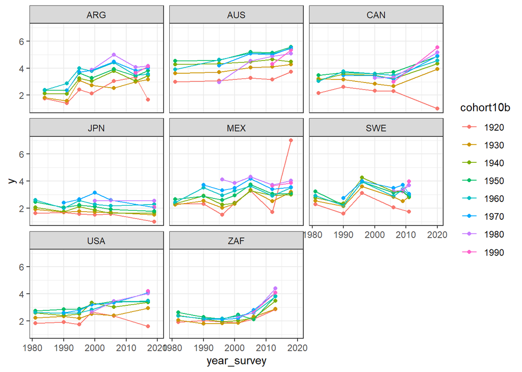

```r
d6_pros <- d6 %>%
  filter(variable == "just_prostitution")

d6_pros %>%
  group_by(country,
           cohort10b,
           year_survey) %>%
  summarize(y = mean(y)) %>%
  ggplot(aes(x = year_survey,
             y = y,
             group = cohort10b,
             color = cohort10b)) +
  geom_point() +
  geom_line() +
  facet_wrap(~country)
```

The pictures here are more complicated than South Africa alone! In fact, for some countries, it might not even make sense to say the average has changed (e.g., JPN). We can think about that later.

Let’s try getting deltas for all countries.

First the function.

```r
get_delta <- function(df) {
  fe1 <- lm(y ~ age01 + I(age01^2) + cohort10b + factor(year_survey),
            data = df)

  at <- anova_test(fe1, detailed = TRUE)

  C_mse <- at[3,2] / at[3,4]
  P_mse <- at[4,2] / at[4,4]

  Delta <- C_mse / (C_mse + P_mse)
  return(Delta)
}
```

Now nest and map

```r
d6_pros %>%
  group_by(country) %>%
  nest() %>%
  mutate(delta = map_dbl(data, get_delta)) %>%
  select(country, delta) %>%
  arrange(delta)
```

```
## # A tibble: 8 × 2
## # Groups:   country [8]
##   country  delta
##   <chr>    <dbl>
## 1 ZAF     0.0101
## 2 SWE     0.0552
## 3 ARG     0.0759
## 4 CAN     0.111
## 5 MEX     0.138
## 6 USA     0.216
## 7 JPN     0.440
## 8 AUS     0.458
```

There’s a good deal of variability here, which means even the same question changes according to different processes in different countries. That’s interesting.

Let’s look at another variable: homosexuality.

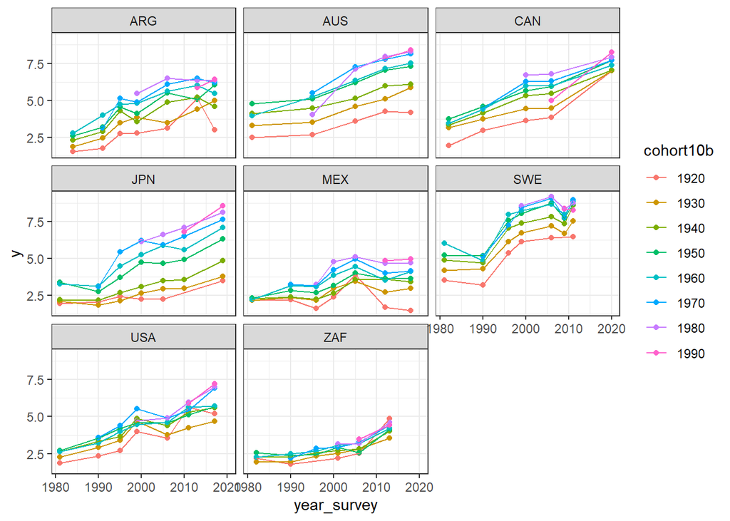

```r
d6_homo <- d6 %>%
  filter(variable == "just_homosexuality")

d6_homo %>%
  group_by(country,
           cohort10b,
           year_survey) %>%
  summarize(y = mean(y)) %>%
  ggplot(aes(x = year_survey,
             y = y,
             group = cohort10b,
             color = cohort10b)) +
  geom_point() +
  geom_line() +
  facet_wrap(~country)
```

```r
d6_homo %>%
  group_by(country) %>%
  nest() %>%
  mutate(delta = map_dbl(data, get_delta)) %>%
  select(country, delta) %>%
  arrange(delta)
```

```
## # A tibble: 8 × 2
## # Groups:   country [8]
##   country   delta
##   <chr>     <dbl>
## 1 ZAF     0.00788
## 2 SWE     0.0595
## 3 USA     0.0727
## 4 MEX     0.0827
## 5 AUS     0.0974
## 6 ARG     0.0988
## 7 CAN     0.109
## 8 JPN     0.289
```

Abortion.

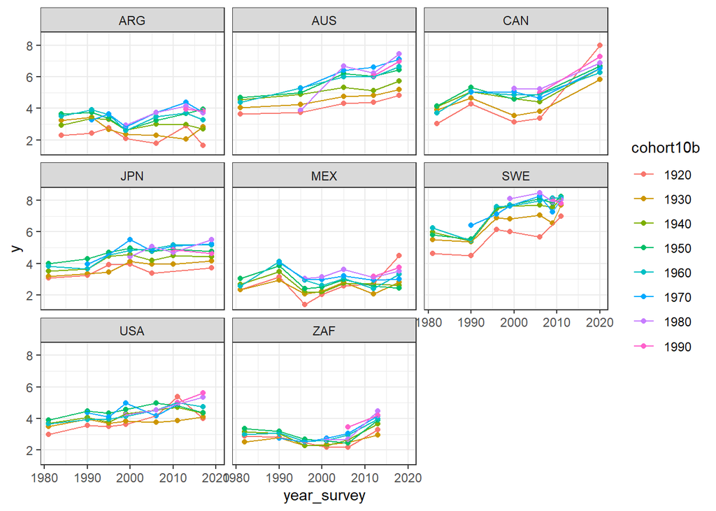

```r
d6_abort <- d6 %>%
  filter(variable == "just_abortion")

d6_abort %>%
  group_by(country,
           cohort10b,
           year_survey) %>%
  summarize(y = mean(y)) %>%
  ggplot(aes(x = year_survey,
             y = y,
             group = cohort10b,
             color = cohort10b)) +
  geom_point() +
  geom_line() +
  facet_wrap(~country)
```

```r
d6_abort %>%
  group_by(country) %>%
  nest() %>%
  mutate(delta = map_dbl(data, get_delta)) %>%
  select(country, delta) %>%
  arrange(delta)
```

```
## # A tibble: 8 × 2
## # Groups:   country [8]
##   country   delta
##   <chr>     <dbl>
## 1 ZAF     0.00873
## 2 MEX     0.0207
## 3 ARG     0.0604
## 4 CAN     0.0716
## 5 AUS     0.0829
## 6 SWE     0.116
## 7 JPN     0.252
## 8 USA     0.280
```

Divorce.

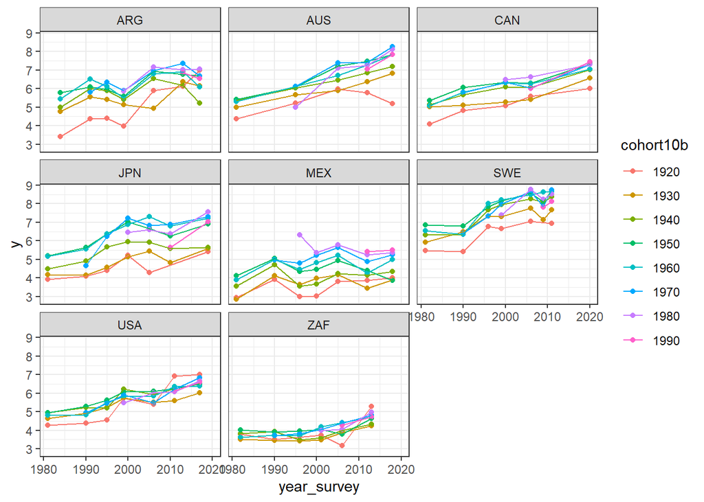

```r
d6_div <- d6 %>%
  filter(variable == "just_divorce")

d6_div %>%
  group_by(country,
           cohort10b,
           year_survey) %>%
  summarize(y = mean(y)) %>%
  ggplot(aes(x = year_survey,
             y = y,
             group = cohort10b,
             color = cohort10b)) +
  geom_point() +
  geom_line() +
  facet_wrap(~country)
```

```r
d6_div %>%
  group_by(country) %>%
  nest() %>%
  mutate(delta = map_dbl(data, get_delta)) %>%
  select(country, delta) %>%
  arrange(delta)
```

```
## # A tibble: 8 × 2
## # Groups:   country [8]
##   country  delta
##   <chr>    <dbl>
## 1 MEX     0.0583
## 2 ZAF     0.0675
## 3 SWE     0.124
## 4 AUS     0.125
## 5 USA     0.150
## 6 CAN     0.258
## 7 ARG     0.291
## 8 JPN     0.299
```

Euthanasia

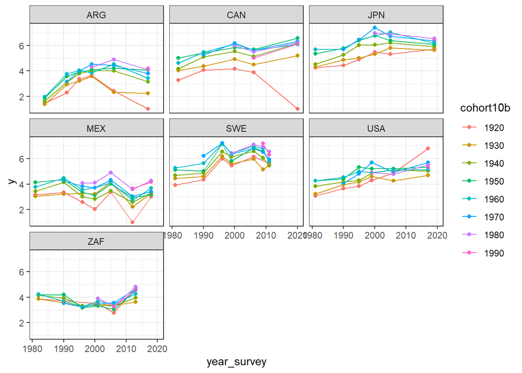

```r
d6_euth <- d6 %>%
  filter(variable == "just_euthanasia")

d6_euth %>%
  group_by(country,
           cohort10b,
           year_survey) %>%
  summarize(y = mean(y)) %>%
  ggplot(aes(x = year_survey,
             y = y,
             group = cohort10b,
             color = cohort10b)) +
  geom_point() +
  geom_line() +
  facet_wrap(~country)
```

```r
d6_euth %>%
  group_by(country) %>%
  nest() %>%
  mutate(delta = map_dbl(data, get_delta)) %>%
  select(country, delta) %>%
  arrange(delta)
```

```
## # A tibble: 7 × 2
## # Groups:   country [7]
##   country  delta
##   <chr>    <dbl>
## 1 ZAF     0.0152
## 2 ARG     0.0258
## 3 SWE     0.0300
## 4 MEX     0.0898
## 5 JPN     0.158
## 6 USA     0.343
## 7 CAN     0.411
```

Suicide

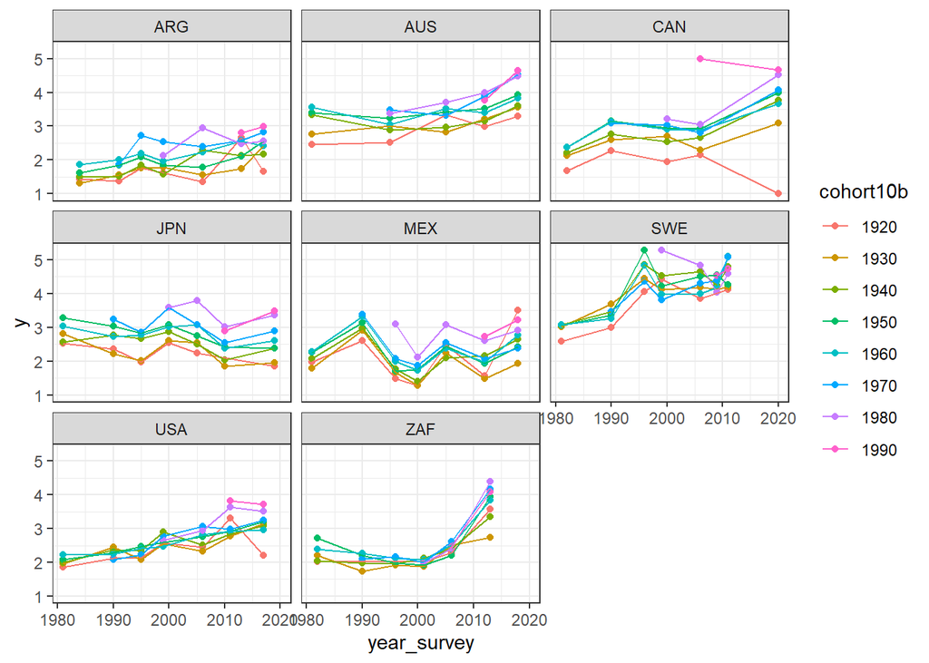

```r
d6_suicide <- d6 %>%
  filter(variable == "just_suicide")

d6_suicide %>%
  group_by(country,
           cohort10b,
           year_survey) %>%
  summarize(y = mean(y)) %>%
  ggplot(aes(x = year_survey,
             y = y,
             group = cohort10b,
             color = cohort10b)) +
  geom_point() +
  geom_line() +
  facet_wrap(~country)
```

```r
d6_suicide %>%
  group_by(country) %>%
  nest() %>%
  mutate(delta = map_dbl(data, get_delta)) %>%
  select(country, delta) %>%
  arrange(delta)
```

```
## # A tibble: 8 × 2
## # Groups:   country [8]
##   country   delta
##   <chr>     <dbl>
## 1 ZAF     0.00412
## 2 MEX     0.0428
## 3 AUS     0.0695
## 4 CAN     0.0702
## 5 SWE     0.0869
## 6 JPN     0.157
## 7 ARG     0.274
## 8 USA     0.485
```

Neig Imm

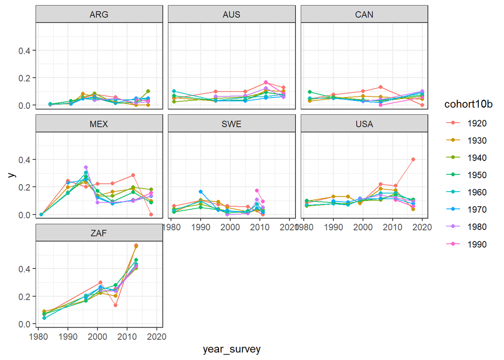

```r
d6_imm <- d6 %>%
  filter(variable == "neigh_imm")

d6_imm %>%
  group_by(country,
           cohort10b,
           year_survey) %>%
  summarize(y = mean(y)) %>%
  ggplot(aes(x = year_survey,
             y = y,
             group = cohort10b,
             color = cohort10b)) +
  geom_point() +
  geom_line() +
  facet_wrap(~country)
```

```r
d6_imm %>%
  group_by(country) %>%
  nest() %>%
  mutate(delta = map_dbl(data, get_delta)) %>%
  select(country, delta) %>%
  arrange(delta)
```

```
## # A tibble: 7 × 2
## # Groups:   country [7]
##   country   delta
##   <chr>     <dbl>
## 1 MEX     0.00302
## 2 ZAF     0.00552
## 3 ARG     0.0299
## 4 USA     0.153
## 5 SWE     0.195
## 6 AUS     0.219
## 7 CAN     0.258
```